# Cyclistic Bike-Share Case Study

Shreha

April 21, 2024

# 🧭 Introduction

Cyclistic is a fictional bike-share company operating in Chicago. The marketing director believes that maximizing the number of annual members is key to long-term success. To support this goal, this analysis compares the riding behaviors of **annual members** vs. **casual riders**, helping to inform future marketing strategies.

# 📂 Data Overview

13 months of trip data (monthly `.csv` files) was used and collected from Cyclistic’s bike-share service. Each record includes trip start/end time, bike type, user type, and location coordinates. This report was prepared on April 21, 2024 based on 13 months of ride data.

Key cleaning steps: - Merged all monthly files into one dataset - Parsed `started_at` and `ended_at` as datetime - Created new variables like `ride_length`, `day_of_week`, `hour`, and `month` - Removed trips with: - Missing data - Ride length ≤ 0 or > 24 hours

# 🔍 Descriptive Analysis

```r
library(tidyverse)
library(lubridate)
library(janitor)
library(ggplot2)
library(scales)

source("scripts/01_clean_and_merge.R")
```

```
## Rows: 5,952,028
## Columns: 13
## $ ride_id            <chr> "CFA86D4455AA1030", "30D9DC61227D1AF3", "846D87A156~
## $ rideable_type      <chr> "classic_bike", "classic_bike", "classic_bike", "cl~
## $ started_at         <dttm> 2021-03-16 08:32:30, 2021-03-28 01:26:28, 2021-03-~
## $ ended_at           <dttm> 2021-03-16 08:36:34, 2021-03-28 01:36:55, 2021-03-~
## $ start_station_name <chr> "Humboldt Blvd & Armitage Ave", "Humboldt Blvd & Ar~
## $ start_station_id   <chr> "15651", "15651", "15443", "TA1308000021", "525", "~
## $ end_station_name   <chr> "Stave St & Armitage Ave", "Central Park Ave & Bloo~
## $ end_station_id     <chr> "13266", "18017", "TA1308000043", "13323", "E008", ~
## $ start_lat          <dbl> 41.91751, 41.91751, 41.84273, 41.96881, 42.01270, 4~
## $ start_lng          <dbl> -87.70181, -87.70181, -87.63549, -87.65766, -87.666~
## $ end_lat            <dbl> 41.91774, 41.91417, 41.83066, 41.95283, 42.05049, 4~
## $ end_lng            <dbl> -87.69139, -87.71676, -87.64717, -87.64999, -87.677~
## $ member_casual      <chr> "casual", "casual", "casual", "casual", "casual", "~
## # A tibble: 2 x 5
##   member_casual avg_ride median_ride max_ride total_rides
##   <chr>            <dbl>       <dbl>    <dbl>       <int>
## 1 casual            27.0       16.1     1440.     2590415
## 2 member            13.4        9.55    1440.     3264011
```

## Average Ride Duration by Day

The dataset includes a total of 5,854,426 ride entries.

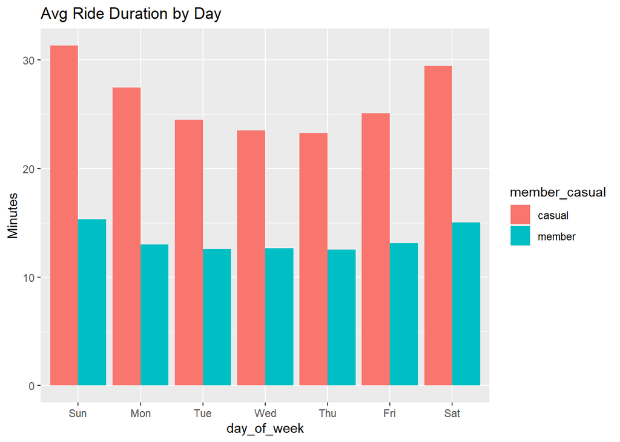

```r
bike_data %>%
  group_by(member_casual, day_of_week) %>%
  summarise(avg_duration = mean(ride_length)) %>%
  ggplot(aes(x = day_of_week, y = avg_duration, fill = member_casual)) +
  geom_col(position = "dodge") +
  labs(title = "Avg Ride Duration by Day", y = "Minutes")
```

## Total Rides by Day of Week

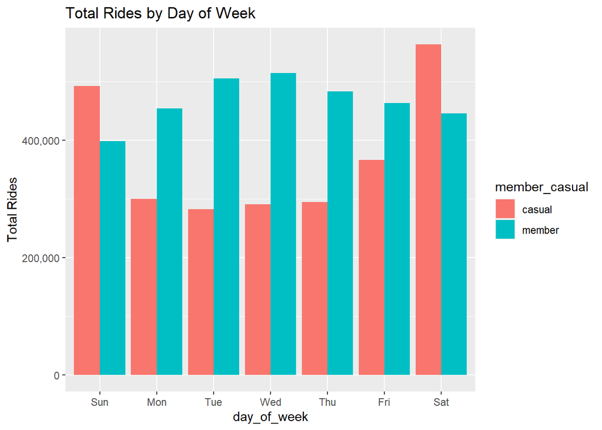

```r
bike_data %>%
  group_by(member_casual, day_of_week) %>%
  summarise(total_rides = n()) %>%
  ggplot(aes(x = day_of_week, y = total_rides, fill = member_casual)) +
  geom_col(position = "dodge") +
  scale_y_continuous(labels = comma) +
  labs(title = "Total Rides by Day of Week", y = "Total Rides")
```

## Ride count by Hour

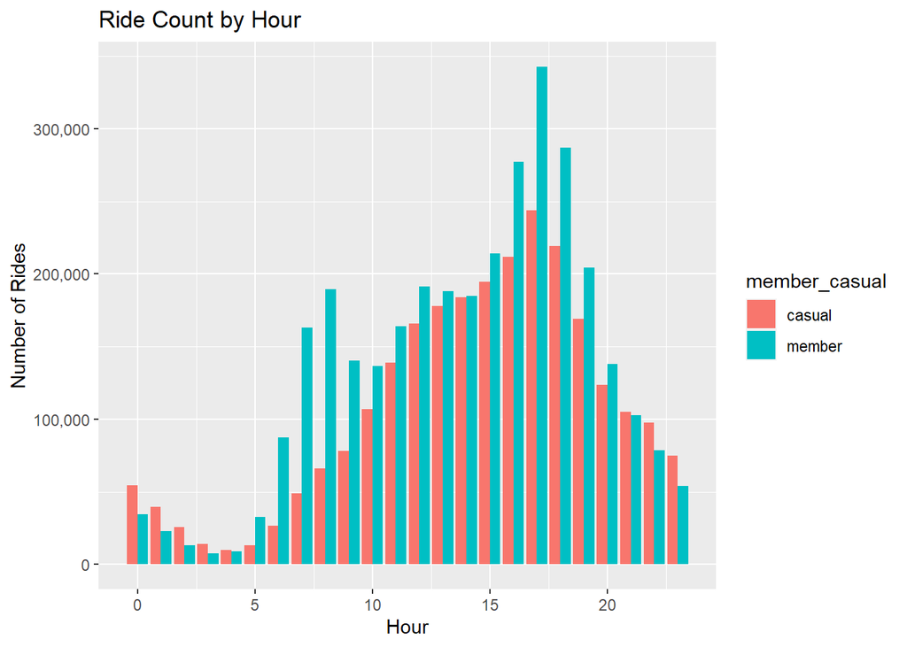

```r
bike_data %>%
  group_by(member_casual, hour) %>%
  summarise(ride_count = n()) %>%
  ggplot(aes(x = hour, y = ride_count, fill = member_casual)) +
  geom_col(position = "dodge") +
  scale_y_continuous(labels = comma) +
  labs(title = "Ride Count by Hour", x = "Hour", y = "Number of Rides")
```

## Most Used Start Stations

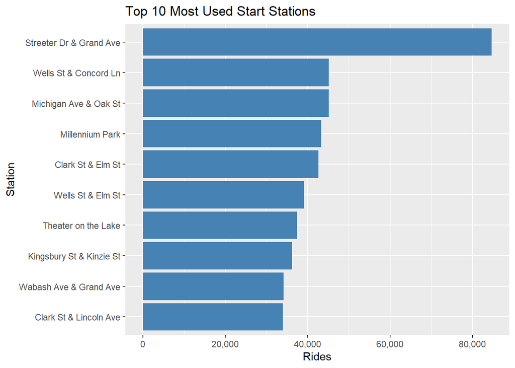

```r
bike_data %>%
  filter(!is.na(start_station_name)) %>%
  group_by(start_station_name) %>%
  summarise(total_rides = n()) %>%
  arrange(desc(total_rides)) %>%
  slice_head(n = 10) %>%
  ggplot(aes(x = reorder(start_station_name, total_rides), y = total_rides)) +
  geom_col(fill = "steelblue") +
  coord_flip() +
  scale_y_continuous(labels = comma) +
  labs(title = "Top 10 Most Used Start Stations", x = "Station", y = "Rides")
```

## Bonus: Map of Ride Start Locations

```r
library(leaflet)

sample_map_data <- bike_data %>%
  filter(!is.na(start_lat) & !is.na(start_lng)) %>%
  slice_sample(n = 1000)

leaflet(sample_map_data) %>%
  addTiles() %>%
  addCircleMarkers(
    lng = ~start_lng,
    lat = ~start_lat,
    color = ~ifelse(member_casual == "member", "blue", "red"),
    radius = 2,
    popup = ~paste("Station:", start_station_name, "<br>Type:", member_casual)
  ) %>%
  addLegend("bottomright",
            colors = c("blue", "red"),
            labels = c("Member", "Casual"),
            title = "User Type")
```

[interactive chart not shown]

## Key Insights

Casual riders take longer rides, especially on weekends.

Members ride more frequently, especially during weekday commutes.

Casual users dominate on Saturdays and Sundays.

Most used start stations are centrally located or tourist-heavy areas.

## Recommendations

Offer weekday discounts or incentives for casual users to increase usage.

Develop targeted promotions for popular weekend locations.

Emphasize the value of membership with ride bundles or commuter perks.

Promote bike-share as a reliable weekday commute alternative for casual users.

## Conclusion

This analysis provides data-driven support to inform Cyclistic’s marketing strategy. By targeting casual riders with relevant incentives and leveraging usage patterns, the company can increase membership and customer retention.